# Investigating clustering of marked/unmarked fish

Author

Collin Edwards

Published

June 5, 2025

## Motivation

Part of the Nisqually Creel Bias analysis involves asking if more anglers are reporting high counts of unmarked encounters more than we expect “should” be happening. The key challenge here is that “should” – how to do we build an expectation for what we think anglers are actually encountering? We use some modeling techniques in our primary analysis, and ultimately (at present) we are leaning towards using a zero-inflated negative binomial error distribution. In non-statsy parlance, we’ve got a framework to say how likely it is that an angler encounters 10 unmarked fish by chance when the average angler is only encountering two or three.

My concern is that that framework assumes the probability of an encountered fish being unmarked is independent of the last few fish caught. If, for example, unmarked fish tended to school together, or unmarked fish prefered a different part of the catch area, then an angler that encounters an unmarked school or is fishing in an unmarked-preferred area is likely to catch quite a few unmarked fish. And if our model does not account for this, our model will find these real encounter numbers suspicious.

The purpose of this document is to look for this kind of pattern, which I’ll call “clumpiness”, but could probably be called “serial correlation”. Is an angler more likely to catch an unmarked fish if the last fish they caught was unmarked?

We can’t really look for this pattern in the Nisqually creel data – after all, the motivation for the Nisqually Creel Bias analysis is that some of the reported surveys may not be correct. Instead, we rely on test fishing data. Unfortunately we do not have test fishing data in the Nisqually, but if there is a tendency for UM and AD clumpiness, we wouldn’t expect it to be unique to the Nisqually. We have a wealth of test fishing data, in which test fishers can be trusted to accurately identify and report the fish that they are encountering. Furthermore, the test fishing surveys provide information on each fish caught, including the time of catch. This means that for each test fishing survey, we have the *order* of fish that were caught. If there is a tendency for clumpiness, then in a long test fishing survey, we tend to see long strings of unmarked fish and long strings of marked fish. If there is not a tendency for clumpiness, then the order of the fish shouldn’t matter. Since we know the total number of marked and unmarked caught in a given survey, we can compare the observed sequence against randomness. By looking across many surveys, we can see if a pattern of clumpiness emerges.

## Summary of results:

The bottom line is we see minimal to no clumpiness. In the test fishing data we get approximately 7% more sequential pairs that are both unmarked than we expect by random chance. Using permutation testing (see Appendix 1), this was marginally significant (P<0.1 but P>0.05). We see an even weaker pattern for sequential pairs that are both marked, occurring approxiately 5% more often than we expect by random change, and this was not significant even at the P = 0.1 level. To contextualize these results of 7% and 5% numbers, imagine that an angler caught 20 fish on the same day. The clumpiness effect (if real) would explain the angler catching one more unmarked fish (or one fewer) than we would expect by random chance. So if there were many anglers on the same day that caught 20 fish, we would see very slightly more surveys with unusual numbers of unmarked fish than we would expect by chance. This is not enough to worry about for our modeling.

If there is interest in further exploration of this pattern for other reasons, using the latitude/longitude of catches and time between catches in the test fishing data could help to clarify whether the minimal observed clumpiness is within a small region or reflects test fishers moving to different parts of a catch area during their survey.

## Setup

```r
library(here)
library(pssp)
library(tidyverse)
library(zoo)
library(doParallel)
library(foreach)
library(car)
library(lme4)
library(gt)
```

To redo the simulations in the appendix, set the following to TRUE.

```r
do.sim = FALSE
```

SQL query to get test fishing data.

```r
## Ty helped with this query
dat_test = pssp_query("-- this is the code for the materialized test fishing view

SELECT s.survey_datetime,
       se.encounter_datetime,
       se.encounter_number,
       s.survey_id,
       spl.sampling_program_code                                                                AS agency,
       cal.catch_area_code,
       crtl.catch_result_type_code,
       --s.start_datetime,
       --s.end_datetime,
      -- array_to_string(array_agg(DISTINCT concat(sa.first_name, ' ', sa.last_name)), ','::text) AS sampler,
       sl.common_name,
       -- array_to_string(array_agg(DISTINCT hll.hooking_location_description), ','::text)         AS hooking_locations,
       -- ppl.pinniped_predation_description,
       -- crtl.catch_result_type_code,
       acsl.adipose_clip_status_code,
       -- flm.length_measurement_centimeter,
       -- fgsl.fishing_gear_size_centimeter,
       -- fglt.fishing_gear_type_description,
       -- flmtl.length_type_description,
       --rhtl.health_type_short_description,
       l.latitude_decimal_degrees_wgs84,
       l.longitude_decimal_degrees_wgs84,
       -- i.genetic_sample_number,
       i.individual_fish_id,
       array_to_string(array_agg(DISTINCT tstl.target_species_type_description), ','::text)     AS target_species
       --s.comment_text                                                                           AS survey_comment,
       --se.comment_text                                                                          AS encounter_comment
FROM survey s
         JOIN survey_sampler ss ON s.survey_id = ss.survey_id
         JOIN sampler sa ON ss.sampler_id = sa.sampler_id
         JOIN survey_type_lut stl ON s.survey_type_id = stl.survey_type_id
         JOIN survey_event se ON s.survey_id = se.survey_id
         JOIN sampling_program_lut spl ON s.sampling_program_id = spl.sampling_program_id
         JOIN location l ON se.encounter_location_id = l.location_id
         JOIN catch_area_lut cal ON se.catch_area_id = cal.catch_area_id
         JOIN fish_encounter fe ON se.survey_event_id = fe.survey_event_id
         LEFT JOIN fishing_gear_size_lut fgsl ON fe.fishing_gear_size_id = fgsl.fishing_gear_size_id
         LEFT JOIN fishing_gear_type_lut fglt ON fe.fishing_gear_type_id = fglt.fishing_gear_type_id
         LEFT JOIN encounter_gear_type_lut egtl ON fe.encounter_gear_type_id = egtl.encounter_gear_type_id
         JOIN species_lut sl ON fe.species_id = sl.species_id
         JOIN adipose_clip_status_lut acsl ON fe.adipose_clip_status_id = acsl.adipose_clip_status_id
         JOIN catch_result_type_lut crtl ON fe.catch_result_type_id = crtl.catch_result_type_id
         LEFT JOIN target_species ts ON se.survey_event_id = ts.survey_event_id
         LEFT JOIN target_species_type_lut tstl ON ts.target_species_type_id = tstl.target_species_type_id
         LEFT JOIN hooking_location hl ON fe.fish_encounter_id = hl.fish_encounter_id
         LEFT JOIN hooking_location_lut hll ON hl.hooking_location_lut_id = hll.hooking_location_lut_id
         LEFT JOIN release_health_type_lut rhtl ON fe.release_health_type_id = rhtl.release_health_type_id
         LEFT JOIN pinniped_predation pp ON fe.fish_encounter_id = pp.fish_encounter_id
         LEFT JOIN pinniped_predation_lut ppl ON pp.pinniped_predation_lut_id = ppl.pinniped_predation_lut_id
         LEFT JOIN individual_fish i ON fe.fish_encounter_id = i.fish_encounter_id
         LEFT JOIN fish_length_measurement flm ON i.individual_fish_id = flm.individual_fish_id
         LEFT JOIN fish_length_measurement_type_lut flmtl
                   ON flm.fish_length_measurement_type_id = flmtl.fish_length_measurement_type_id
WHERE stl.survey_type_description::text = 'Puget Sound test fishing survey'::text
  AND se.void_encounter_indicator = false
GROUP BY s.survey_datetime, se.encounter_datetime, spl.sampling_program_code, cal.catch_area_code, s.start_datetime,
         s.end_datetime, sl.common_name, ppl.pinniped_predation_description, crtl.catch_result_type_code,
         acsl.adipose_clip_status_code, flm.length_measurement_centimeter, fgsl.fishing_gear_size_centimeter,
         fglt.fishing_gear_type_description, flmtl.length_type_description, rhtl.health_type_short_description,
         l.latitude_decimal_degrees_wgs84, l.longitude_decimal_degrees_wgs84, i.genetic_sample_number,
         i.individual_fish_id, s.comment_text, se.comment_text, se.encounter_number, s.survey_id
")
## Need to give encounter number to those that are missing it -- order by datetime.
```

Process the data

```r
dat <- dat_test |>
  filter(common_name == "Chinook Salmon",
         adipose_clip_status_code %in% c("AD", "UM"),
         catch_result_type_code %in% c("R", "K")) |>
  ## SUPER IMPORTANT: There are DUPLICATE entries of fish because of multiple measurement types. Super annoying.
  ## removing duplicates here.
  select(-encounter_number) |>
  distinct() |>
  group_by(survey_id) |>
  arrange(encounter_datetime) |>
  mutate(encounter_id = 1:n(),
         .after = encounter_datetime) |>
  mutate(min_since_last = (as.numeric(encounter_datetime) - as.numeric(lag(encounter_datetime)))/60) |>
  ungroup() |>
  mutate(year = year(survey_datetime),
         .before = survey_datetime) |>
  select(-survey_datetime,
         -latitude_decimal_degrees_wgs84,
         -longitude_decimal_degrees_wgs84,
         -agency
  )

dat_survey_simplified = tibble(survey_id = unique(dat$survey_id)) |>
  mutate(survey_id_simplified = seq_along(survey_id))

dat = left_join(dat, dat_survey_simplified, by = "survey_id") |>
  relocate(survey_id_simplified, .before = survey_id) |>
  select(-survey_id)

survey_summaries = dat |>
  group_by(survey_id_simplified) |>
  summarize(total_um = sum(adipose_clip_status_code == "UM"),
            total_ad = sum(adipose_clip_status_code == "AD"))


dat = left_join(dat, survey_summaries, by = "survey_id_simplified")
```

Using only surveys with 4 or more unmarked and 4 or more marked encounters. We can’t really observe clumpiness unless we have several fish of each mark type.

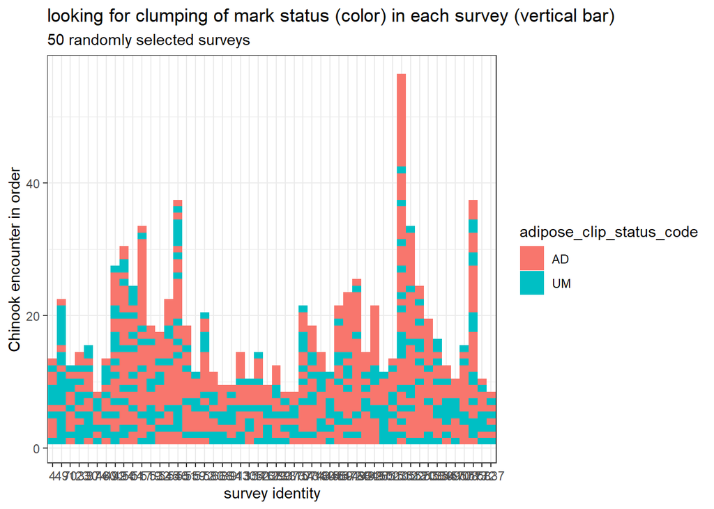

```r
dat_robust = dat |>
  filter(total_um > 3,
         total_ad > 3)

##Okay, our data is ready!
dat_robust |>
  filter(survey_id_simplified %in% sample(unique(dat_robust$survey_id_simplified), 50)) |>
  mutate(survey_id_simplified = as.factor(survey_id_simplified)) |>
  ggplot(aes(x = survey_id_simplified, y = encounter_id, fill = adipose_clip_status_code))+
  geom_tile()+
  theme_bw()+
  labs(x = "survey identity",
       y = "Chinook encounter in order",
       title = "looking for clumping of mark status (color) in each survey (vertical bar)",
       subtitle = "50 randomly selected surveys")
```

Checking that we’re not looking across multiple areas in a single survey

```r
dat_robust |>
  select(survey_id_simplified, catch_area_code) |>
  distinct() |>
  pull(survey_id_simplified) |>
  table() |>
  table()
```

```
  1
428
```

looks good

## Approach: frequency of sequential pairs

Do we see more sequential pairs of the same type (UM and then UM or AD and then AD) than we would expect if fish order was random? Looking at catch of a survey sequentially, we can calculate the frequency of each pair type. If there is a tendency for clumpiness, our same-type pairs should be more frequent than expected, and UM -> AD and AD -> UM should be less frequent than expected.

### The maths

The tricky part here is “how frequently do we expect a pair?”. If there is no clumping, then the sequence of fish caught in a survey should be indistinguishable from randomly reordering those same catches. If we were randomly shuffling the fish in a survey had a huge number of fish in it, we would expect the probability of UM -> UM to be

$f(UM)f(UM)$

and, since for a survey with $m$ fish in it there are $(m-1)$ pairs, we expect to see on average

$(m-1)f(UM)f(UM)$

pairs, Where $f(UM)$ is the proportion of the fish in that survey that were unmarked. Analogously, if we were drawing marbles out of a jar with a ton of red and blue marbles in it, the probability of drawing two red marbles in order should be approximately the proportion of marbles in the jar that are red, squared.

However, when we have a limited supply of marbles (or a survey with a finite number of fish in it), when we’re looking at a pair of fish in sequence, we need to account for the fact that when we’re drawing the second marble (or fish), the first marble (or fish) is already missing. For example, let’s imagine a survey with 6 unmarked and 4 marked fish. Our probability of drawing an unmarked fish is $\frac{6}{10}$. But to have a UM->UM pair, we need to first draw an unmarked fish ($\frac{6}{10}$ chance) and *then* draw an unmarked fish *from the remaining available fish, which has a chance of $\frac{5}{9}$.

More generally, for a sequential pair of fish that have the same mark status, we have probabilities of

$\frac{f(UM)}{m}\frac{f(UM)-1}{m-1}$

and

$\frac{f(AD)}{m}\frac{f(AD)-1}{m-1}$

for UM->UM and AD -> AD respectively.

If we do the same math above for the AD->UM or UM->AD pairs, we find we don’t need the $-1$ in the numerators. With our example survey, an AD -> UM pair has a probability of first drawing an AD ($\frac{4}{10}$) and then drawing a UM from the remaining fish ($\frac{6}{9}$). More generally, this works out to be

$\frac{f(AD)}{m}\frac{f(UM)}{m-1}$

and the probability of UM -> AD is

$\frac{f(UM)}{m}\frac{f(AD)}{m-1}$

(conveniently, these two produce the same values, as they are just reordering of the same operations).

Now that we have an expectation for what we should see if there were no clumpiness tendencies, we can look at the observed data and see if has a tendency for clumping.

### Coding framework

```r
## functions to help
## this takes two fish clip statuses and returns the transition type
find_transition = function(fin_pair){
  if(length(fin_pair) != 2){
    cli::cli_abort("need exactly two fish for transition")
  }
  case_when(
    fin_pair[1] == "UM" & fin_pair[2] == "UM" ~ "UM->UM",
    fin_pair[1] == "UM" & fin_pair[2] == "AD" ~ "UM->AD",
    fin_pair[1] == "AD" & fin_pair[2] == "UM" ~ "AD->UM",
    fin_pair[1] == "AD" & fin_pair[2] == "AD" ~ "AD->AD"
  )
}

find_transition_probs = function(survey_fins){
  #had some difficulties with the base probabilities, but I finally worked it out, I think
  #What is the frequency of each pair of fin types? With infinite sequence of fish we can use a simplification,
  #but for finite fish, we have a lower probability of observing doubles because we have used up one of the available clips in the first fish of the pair.
  #I think? Testing on a simple case seems to work well, but it's producing potentially biased results for bigger permutation sims.
  freq_um = sum(survey_fins == "UM")
  freq_ad = sum(survey_fins == "AD")
  transitions = rollapply(survey_fins, width = 2, FUN = find_transition)
  res = tibble(um_to_um = sum(transitions == "UM->UM"),
               ad_to_um = sum(transitions == "AD->UM"),
               um_to_ad = sum(transitions == "UM->AD"),
               ad_to_ad = sum(transitions == "AD->AD"),
               um_to_um_pred = freq_um * (freq_um - 1) / length(survey_fins), #subtracting kronecker delta
               ad_to_um_pred = freq_ad * (freq_um - 0) / length(survey_fins), #subtracting kronecker delta
               um_to_ad_pred = freq_um * (freq_ad - 0) / length(survey_fins), #subtracting kronecker delta
               ad_to_ad_pred = freq_ad * (freq_ad - 1) / length(survey_fins), #subtracting kronecker delta
  )
  ## the following isn't doing the normalization right, as my sims below identified.
  ## The um_to_um transition is going to be far more common that ad_to_um if um is more common.
  res$um_to_um_diff = res$um_to_um - res$um_to_um_pred
  res$ad_to_um_diff = res$ad_to_um - res$ad_to_um_pred
  res$um_to_ad_diff = res$um_to_ad - res$um_to_ad_pred
  res$ad_to_ad_diff = res$ad_to_ad - res$ad_to_ad_pred
  return(res)
}
```

### Quick test:

```r
nsim = 1000
um_to_um_null = numeric(nsim)
res.list = list()
for(i in 1:nsim){
  temp = sample(c(rep("UM", 6), rep("AD", 6)))
  res.temp = find_transition_probs(temp)
  res.list[[i]] = res.temp
  um_to_um_null[i] = res.temp$um_to_um_diff
}
mean(um_to_um_null)
```

```
[1] 0.035
```

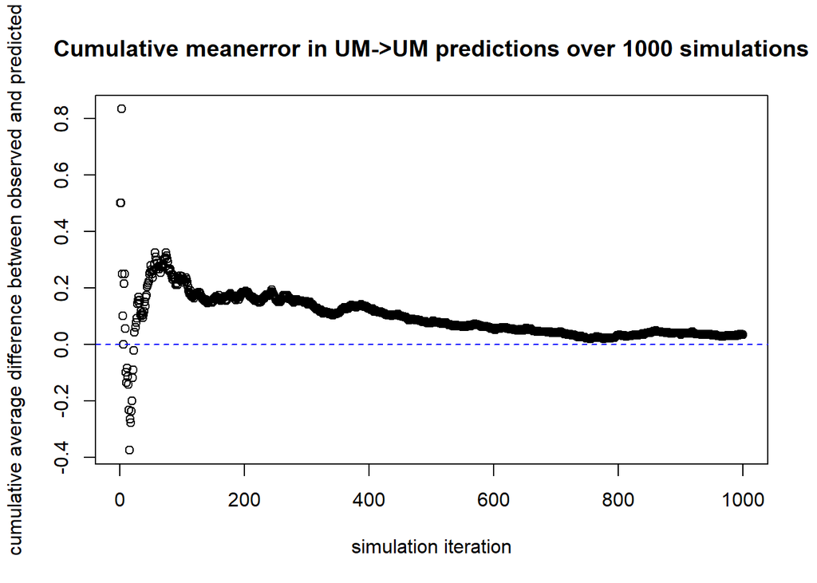

```r
plot(cummean(um_to_um_null),
     xlab = "simulation iteration",
     ylab = "cumulative average difference between observed and predicted",
     main = "Cumulative meanerror in UM->UM predictions over 1000 simulations")
abline(h = 0, lty = 2, col = 'blue')
```

This looks pretty good.

### Looking at our data

```r
survey_transitions = dat_robust |>
  arrange(survey_id_simplified, survey_id_simplified) |>
  nest(.by = c(year, survey_id_simplified)) |>
  mutate(transitions = purrr::map_df(data,
                                     function(df){find_transition_probs(df$adipose_clip_status_code)})) |>
  select(-data) |>
  unnest(transitions)

## Summary
obs_probs = survey_transitions |>
  summarize(um_to_um_diff = mean(um_to_um_diff),
            ad_to_um_diff = mean(ad_to_um_diff),
            um_to_ad_diff = mean(um_to_ad_diff),
            ad_to_ad_diff = mean(ad_to_ad_diff)) |>
  ungroup()
```

For each survey, we calculate how the number of UM->UM and AD->AD pairs from what we expect if the sequence of fish caught was random. Here are the histograms of that, along with the median across surveys.

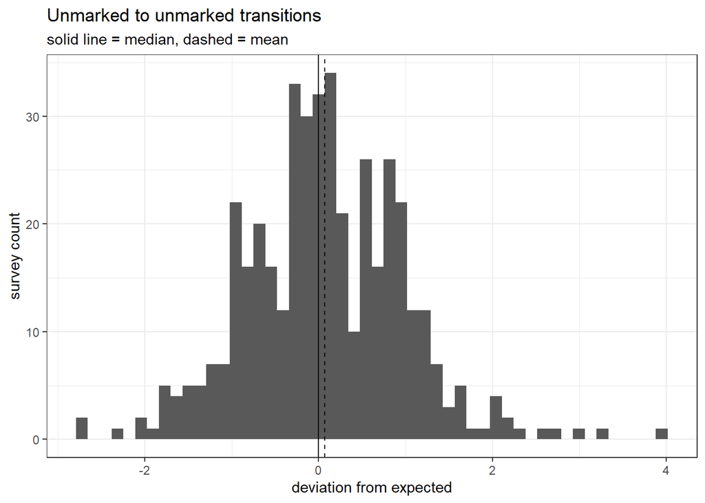

```r
ggplot(survey_transitions,
       aes(x = um_to_um_diff))+
  geom_histogram(bins = 50)+
  geom_vline(xintercept = median(survey_transitions$um_to_um_diff))+
  geom_vline(xintercept = mean(survey_transitions$um_to_um_diff), linetype = 2)+
  theme_bw()+
  labs(x = "deviation from expected",
       y = "survey count",
       title = "Unmarked to unmarked transitions",
       subtitle = "solid line = median, dashed = mean")
```

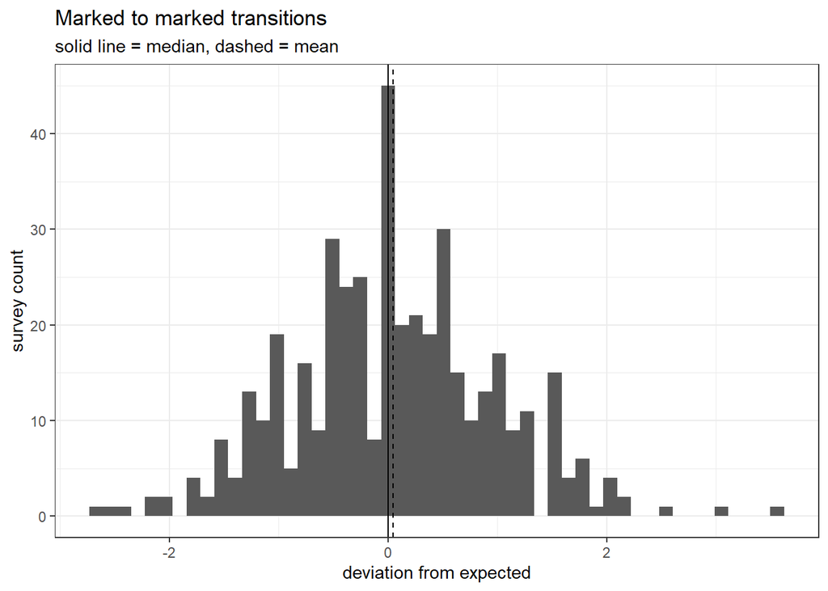

```r
ggplot(survey_transitions,
       aes(x = ad_to_ad_diff))+
  geom_histogram(bins = 50)+
  geom_vline(xintercept = median(survey_transitions$ad_to_ad_diff))+
  geom_vline(xintercept = mean(survey_transitions$ad_to_ad_diff), linetype = 2)+
  theme_bw()+
  labs(x = "deviation from expected",
       y = "survey count",
       title = "Marked to marked transitions",
       subtitle = "solid line = median, dashed = mean")
```

That is pretty darn convincing that there is no special clumpiness tendencies.

Here are the average deviations from expectations for each pair type:

```r
obs_probs |> gt()
```

| um_to_um_diff | ad_to_um_diff | um_to_ad_diff | ad_to_ad_diff |
| --- | --- | --- | --- |
| 0.07046905 | -0.06178183 | -0.05477248 | 0.04608527 |

If there *is* a tendency for clumpiness, it’s on the order of getting about 1 more pair of UM->UM or AD->AD than expected for every 21 fish caught (20 pairs). This could just be noise, or it could reflect the fact that test fishing surveys often represent long fishing bouts, and test fishers may move from one region to another (within a catch area) during that survey. If there are spatial differences in mark rates within catch areas and test fishers move during their surveys, we do expect there would be slight clumpiness.

This is something we could dig into further by using test fisher lat/lon to break surveys up into sub-surveys of fish caught within a small region – we would not expect spatial variation in mark rates to produce clumpiness in that case. However, for the purposes of the nisqually creel bias analysis, we have done enough. This tendency for clumpiness is very small (if, in fact, it is anything more than noise), and is unlikely to explain angler surveys with abnormally high numbers of unmarked catch.

## Appendix 1: Permutation testing of actual data

This analysis has involved some complicated calculations. To confirm that my approach is doing what I think it should, I simulated our null expectation (fish order doesn’t matter) using the actual data. For each of 1000 simulation iterations, I took the full dataset, randomly reordered the fish caught within each survey (total UM and AD fish caught in a survey stayed the same), and ran the full analysis above. This is relatively time consuming (~20 minutes on my computer), so I have saved the results for easier use. Set `do.sim` argument at the beginning of this script to `TRUE` to rerun the simulations; otherwise the past results get read in.

```r
if(do.sim){
  cl <- makeCluster(6)
  registerDoParallel(cl)
  nsim = 1000
  sim.ls = foreach(i = 1:nsim,
                   .packages = c("tidyverse", "zoo")) %dopar% {
                     sim.ls[[i]] = dat_robust |>
                       arrange(survey_id_simplified, survey_id_simplified) |>
                       nest(.by = c(year, survey_id_simplified)) |>
                       mutate(transitions = purrr::map_df(data,
                                                          function(df){find_transition_probs(sample(df$adipose_clip_status_code))})) |>
                       select(-data) |>
                       unnest(transitions) |>
                       summarize(um_to_um_diff = mean(um_to_um_diff),
                                 ad_to_um_diff = mean(ad_to_um_diff),
                                 um_to_ad_diff = mean(um_to_ad_diff),
                                 ad_to_ad_diff = mean(ad_to_ad_diff))
                   }
  stopCluster(cl)

  sim.probs = do.call(rbind, sim.ls)
  write_csv(sim.probs,
            here("results/simulations/clumpiness-markov-null-sims.csv"))
} else {
  sim.probs = read_csv(here("results/simulations/clumpiness-markov-null-sims.csv"))
}
```

For each simulation, we calculated the average deviation of UM->UM and AD->AD pair frequency from our expectation. In our actual data, we found values of 0.0705 and 0.0461 for those average deviations.

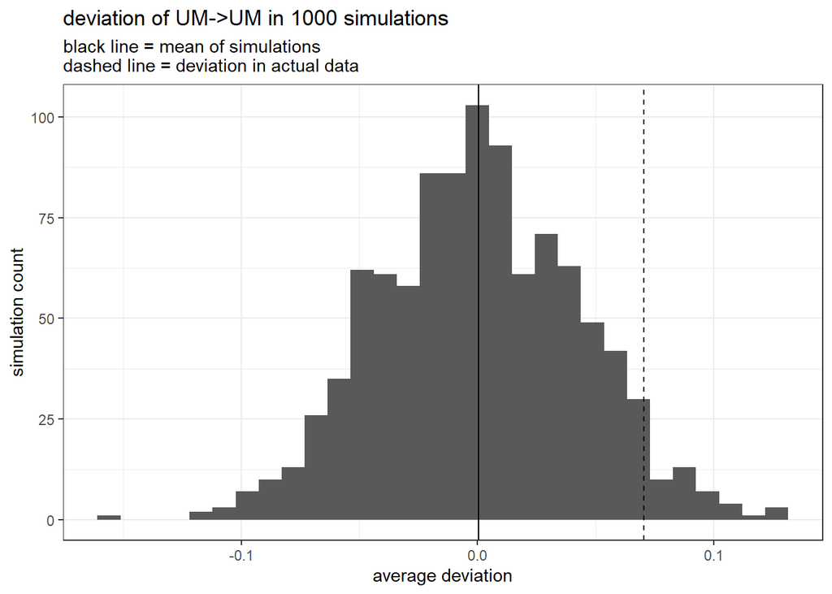

```r
sim.probs |>
  ggplot(aes(x = um_to_um_diff))+
  geom_histogram()+
  geom_vline(xintercept = obs_probs$um_to_um_diff, linetype = 2)+
  geom_vline(xintercept = mean(sim.probs$um_to_um_diff), linetype = 1)+
  labs(x = "average deviation",
       y = "simulation count",
       title = "deviation of UM->UM in 1000 simulations",
       subtitle = "black line = mean of simulations\ndashed line = deviation in actual data")+
  theme_bw()
```

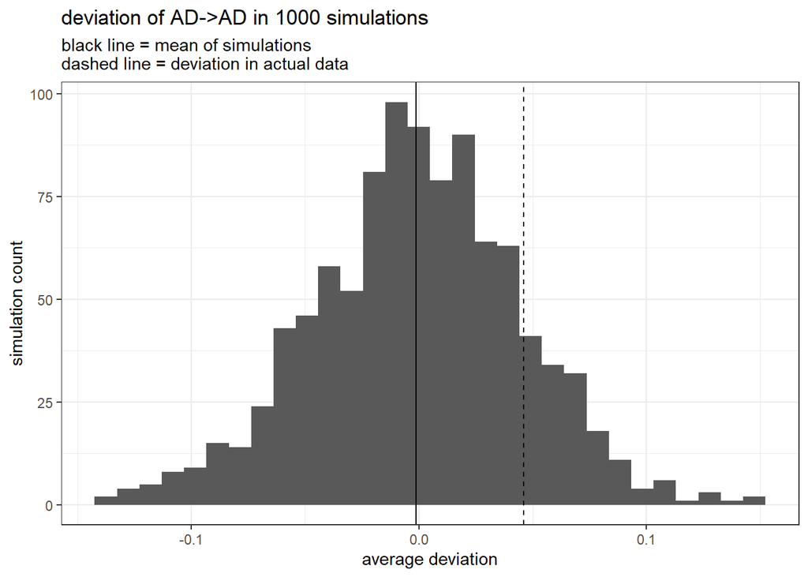

```r
sim.probs |>
  ggplot(aes(x = ad_to_ad_diff))+
  geom_histogram()+
  geom_vline(xintercept = obs_probs$ad_to_ad_diff, linetype = 2)+
  geom_vline(xintercept = mean(sim.probs$ad_to_ad_diff), linetype = 1)+
  labs(x = "average deviation",
       y = "simulation count",
       title = "deviation of AD->AD in 1000 simulations",
       subtitle = "black line = mean of simulations\ndashed line = deviation in actual data")+
  theme_bw()
```

We can look at the 95% and 90% ranges of simulated average UM->UM deviations and see if our observed average deviation fell outside of those; this is equivalent to testing for significance at the P < 0.05 and P < 0.1 levels. As a reminder, because we use 2-tailed tests, data is outside of the range of 90% of the data (significant at the P<0.1 level) if is less than 0.05 quantile or greater than the 0.95 quantile. Here are quantiles from the simulations:

```r
quantile(sim.probs$um_to_um_diff, probs = c(0.025, 0.05, 0.95, 0.975))
```

```
       2.5%          5%         95%       97.5%
-0.07912208 -0.06738142  0.06813260  0.08682419
```

We can do a similar procedure for AD->AD deviations

```r
quantile(sim.probs$ad_to_ad_diff, probs = c(0.025, 0.05, 0.95, 0.975))
```

```
       2.5%          5%         95%       97.5%
-0.09416006 -0.07774651  0.07178620  0.08580489
```

Our observed deviation of 0.0461 was not significant at the P<0.1 level.